# Peer Assessment 1 of Reproducible Research

Marcus Mariano

friday, february 12, 2016

## Loading and preprocessing the data

Loading data

```r
data <- read.table(unz("activity.zip", "activity.csv"), sep = ",",
                  header = TRUE, stringsAsFactors = F)
```

Process and transform the data

```r
## tidy data
dat <- data
## format the date
dat$date <- as.Date(dat$date, "%Y-%m-%d")
## change to NA the 0 values from steps and interval
dat$steps[dat$steps < 1] <- NA
```

## What is mean total number of steps taken per day?

Total number of steps taken per day

```r
##  calculate total number of steps taken per day
total_step_day <- tapply(dat$steps, dat$date, sum, na.rm = TRUE)
```

Histogram of the total number of steps taken each day

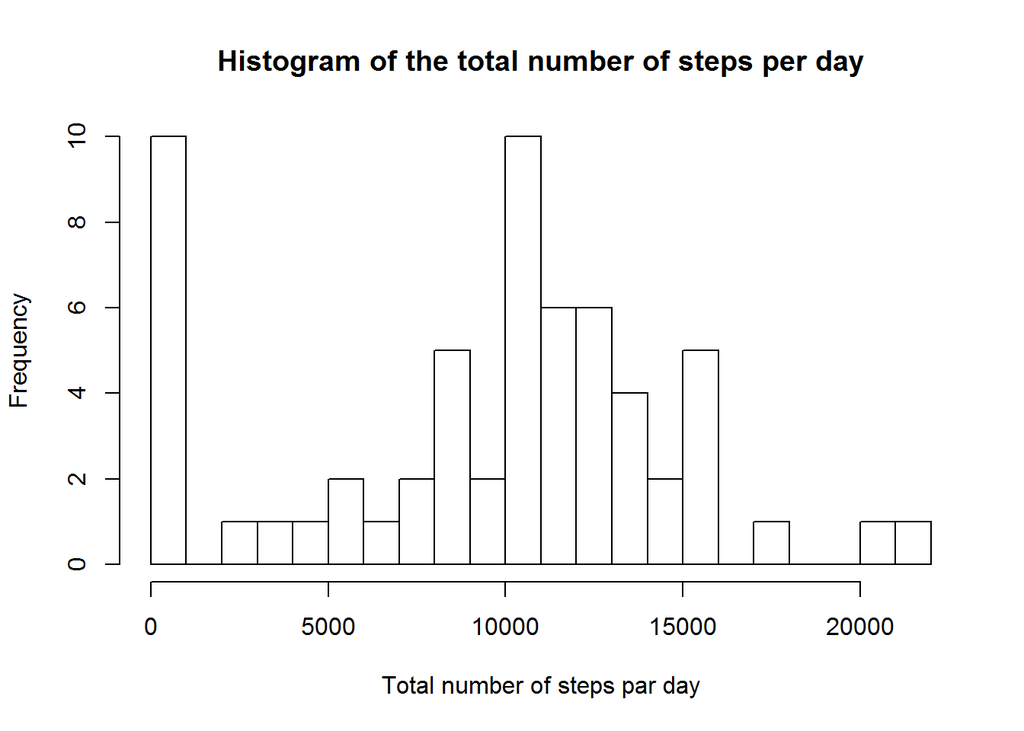

```r
hist(total_step_day, breaks = 18, xlab="Total number of steps par day",
     main="Histogram of the total number of steps per day",
      xlim=c(0, 22000))
```

Mean of the total number of steps taken per day

```r
total_mean_day <- tapply(dat$steps, dat$date, mean, na.rm = TRUE)
total_mean_day
```

```
## 2012-10-01 2012-10-02 2012-10-03 2012-10-04 2012-10-05 2012-10-06
##        NaN   63.00000  140.14815  121.16000  154.58140  145.47170
## 2012-10-07 2012-10-08 2012-10-09 2012-10-10 2012-10-11 2012-10-12
##  101.99074        NaN  134.85263   95.19231  137.38667  156.59459
## 2012-10-13 2012-10-14 2012-10-15 2012-10-16 2012-10-17 2012-10-18
##  119.48077  160.61702  131.67532  157.12500  152.86364  152.36364
## 2012-10-19 2012-10-20 2012-10-21 2012-10-22 2012-10-23 2012-10-24
##  127.19355  125.24096   96.93407  154.71264  101.34091  104.43750
## 2012-10-25 2012-10-26 2012-10-27 2012-10-28 2012-10-29 2012-10-30
##   56.63636   77.02273  134.92000  110.17308   80.93548  110.32584
## 2012-10-31 2012-11-01 2012-11-02 2012-11-03 2012-11-04 2012-11-05
##  179.23256        NaN  143.24324  117.45556        NaN  141.06757
## 2012-11-06 2012-11-07 2012-11-08 2012-11-09 2012-11-10 2012-11-11
##  100.40964  135.61053   61.90385        NaN        NaN  132.71579
## 2012-11-12 2012-11-13 2012-11-14 2012-11-15 2012-11-16 2012-11-17
##  156.01449   90.56790        NaN   20.50000   89.19672  183.83333
## 2012-11-18 2012-11-19 2012-11-20 2012-11-21 2012-11-22 2012-11-23
##  162.47312  117.88000   95.14894  188.04412  177.62609  252.30952
## 2012-11-24 2012-11-25 2012-11-26 2012-11-27 2012-11-28 2012-11-29
##  176.56098  140.88095  128.29885  158.67442  212.14583  110.10938
## 2012-11-30
##        NaN
```

Median of the total number of steps taken per day

```r
total_media_day <- tapply(dat$steps, dat$date, median, na.rm = TRUE)
total_media_day
```

```
## 2012-10-01 2012-10-02 2012-10-03 2012-10-04 2012-10-05 2012-10-06
##         NA       63.0       61.0       56.5       66.0       67.0
## 2012-10-07 2012-10-08 2012-10-09 2012-10-10 2012-10-11 2012-10-12
##       52.5         NA       48.0       56.5       35.0       46.0
## 2012-10-13 2012-10-14 2012-10-15 2012-10-16 2012-10-17 2012-10-18
##       45.5       60.5       54.0       64.0       61.5       52.5
## 2012-10-19 2012-10-20 2012-10-21 2012-10-22 2012-10-23 2012-10-24
##       74.0       49.0       48.0       52.0       56.0       51.5
## 2012-10-25 2012-10-26 2012-10-27 2012-10-28 2012-10-29 2012-10-30
##       35.0       36.5       72.0       61.0       54.5       40.0
## 2012-10-31 2012-11-01 2012-11-02 2012-11-03 2012-11-04 2012-11-05
##       83.5         NA       55.5       59.0         NA       66.0
## 2012-11-06 2012-11-07 2012-11-08 2012-11-09 2012-11-10 2012-11-11
##       52.0       58.0       42.5         NA         NA       55.0
## 2012-11-12 2012-11-13 2012-11-14 2012-11-15 2012-11-16 2012-11-17
##       42.0       57.0         NA       20.5       43.0       65.5
## 2012-11-18 2012-11-19 2012-11-20 2012-11-21 2012-11-22 2012-11-23
##       80.0       34.0       58.0       55.0       65.0      113.0
## 2012-11-24 2012-11-25 2012-11-26 2012-11-27 2012-11-28 2012-11-29
##       65.5       84.0       53.0       57.0       70.0       44.5
## 2012-11-30
##         NA
```

## What is the average daily activity pattern?

Series plot of the 5-minute interval and the average number of steps

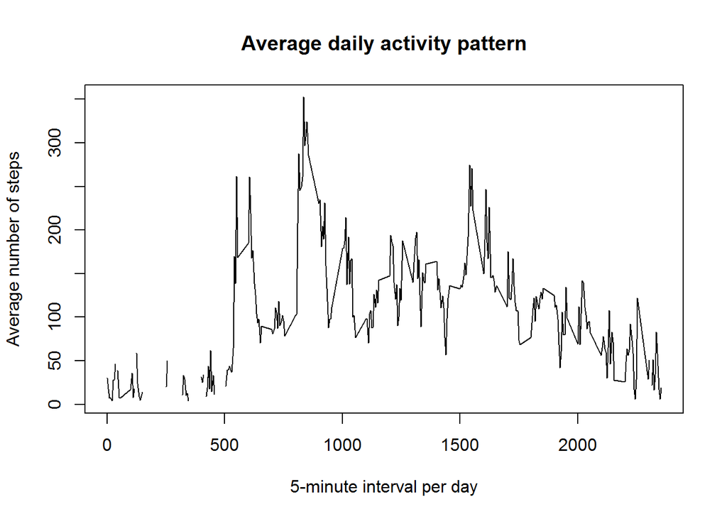

```r
interval_day <- tapply(dat$steps, dat$interval, mean, na.rm = TRUE)
interlist <- unique(dat$interval)

in_st <- data.frame(interval = interlist, steps = interval_day)

plot(in_st$interval, in_st$steps, type = "l", xlab = "5-minute interval per day",
     ylab = "Average number of steps",
     main = "Average daily activity pattern")
```

maximum number of steps on 5-minute interval

```r
max(interval_day, na.rm = TRUE)
```

```
## [1] 352.4839
```

## Imputing missing values

Total number of missing values in the dataset

```r
sum(is.na(dat))
```

```
## [1] 13318
```

Filling in all of the missing values in the dataset.

```r
dat_new  <- dat ## new data

## the mean for that 5-minute interval
dat_new[is.na(dat_new)] <- mean(interval_day, na.rm = TRUE) ## fill NA's per mean steps per day
```

New dataset with the missing data filled in

```r
head(dat_new, 20)
```

```
##       steps       date interval
## 1  107.9516 2012-10-01        0
## 2  107.9516 2012-10-01        5
## 3  107.9516 2012-10-01       10
## 4  107.9516 2012-10-01       15
## 5  107.9516 2012-10-01       20
## 6  107.9516 2012-10-01       25
## 7  107.9516 2012-10-01       30
## 8  107.9516 2012-10-01       35
## 9  107.9516 2012-10-01       40
## 10 107.9516 2012-10-01       45
## 11 107.9516 2012-10-01       50
## 12 107.9516 2012-10-01       55
## 13 107.9516 2012-10-01      100
## 14 107.9516 2012-10-01      105
## 15 107.9516 2012-10-01      110
## 16 107.9516 2012-10-01      115
## 17 107.9516 2012-10-01      120
## 18 107.9516 2012-10-01      125
## 19 107.9516 2012-10-01      130
## 20 107.9516 2012-10-01      135
```

[figure not shown]

Calculate mean and median total number of steps taken per day

```r
new_mean_day <- tapply(dat_new$steps, dat_new$date, mean, na.rm = TRUE)
new_mean_day ## mean total number of steps taken per day
```

```
## 2012-10-01 2012-10-02 2012-10-03 2012-10-04 2012-10-05 2012-10-06
##  107.95157  107.63941  117.00686  112.53783  121.87575  121.76106
## 2012-10-07 2012-10-08 2012-10-09 2012-10-10 2012-10-11 2012-10-12
##  105.71626  107.95157  116.82519  103.34406  115.61696  126.69940
## 2012-10-13 2012-10-14 2012-10-15 2012-10-16 2012-10-17 2012-10-18
##  112.11489  125.14099  114.29438  124.34271  121.67470  118.12934
## 2012-10-19 2012-10-20 2012-10-21 2012-10-22 2012-10-23 2012-10-24
##  114.16513  112.93428  104.47035  122.07731  105.93165  106.97544
## 2012-10-25 2012-10-26 2012-10-27 2012-10-28 2012-10-29 2012-10-30
##  100.11175   98.50109  114.97460  108.75378  102.13561  108.68529
## 2012-10-31 2012-11-01 2012-11-02 2012-11-03 2012-11-04 2012-11-05
##  129.23687  107.95157  117.01957  110.92157  107.95157  116.46054
## 2012-11-06 2012-11-07 2012-11-08 2012-11-09 2012-11-10 2012-11-11
##  105.77803  117.07519   99.63740  107.95157  107.95157  116.12032
## 2012-11-12 2012-11-13 2012-11-14 2012-11-15 2012-11-16 2012-11-17
##  119.46665  103.06241  107.95157  107.34427  103.97919  128.50288
## 2012-11-18 2012-11-19 2012-11-20 2012-11-21 2012-11-22 2012-11-23
##  125.55749  110.53710  105.86225  126.86231  135.77299  150.05597
## 2012-11-24 2012-11-25 2012-11-26 2012-11-27 2012-11-28 2012-11-29
##  127.48619  117.55597  114.09815  123.09798  125.31728  108.43108
## 2012-11-30
##  107.95157
```

```r
new_media_day <- tapply(dat_new$steps, dat_new$date, median, na.rm = TRUE)
new_media_day ## media total number of steps taken per day
```

```
## 2012-10-01 2012-10-02 2012-10-03 2012-10-04 2012-10-05 2012-10-06
##   107.9516   107.9516   107.9516   107.9516   107.9516   107.9516
## 2012-10-07 2012-10-08 2012-10-09 2012-10-10 2012-10-11 2012-10-12
##   107.9516   107.9516   107.9516   107.9516   107.9516   107.9516
## 2012-10-13 2012-10-14 2012-10-15 2012-10-16 2012-10-17 2012-10-18
##   107.9516   107.9516   107.9516   107.9516   107.9516   107.9516
## 2012-10-19 2012-10-20 2012-10-21 2012-10-22 2012-10-23 2012-10-24
##   107.9516   107.9516   107.9516   107.9516   107.9516   107.9516
## 2012-10-25 2012-10-26 2012-10-27 2012-10-28 2012-10-29 2012-10-30
##   107.9516   107.9516   107.9516   107.9516   107.9516   107.9516
## 2012-10-31 2012-11-01 2012-11-02 2012-11-03 2012-11-04 2012-11-05
##   107.9516   107.9516   107.9516   107.9516   107.9516   107.9516
## 2012-11-06 2012-11-07 2012-11-08 2012-11-09 2012-11-10 2012-11-11
##   107.9516   107.9516   107.9516   107.9516   107.9516   107.9516
## 2012-11-12 2012-11-13 2012-11-14 2012-11-15 2012-11-16 2012-11-17
##   107.9516   107.9516   107.9516   107.9516   107.9516   107.9516
## 2012-11-18 2012-11-19 2012-11-20 2012-11-21 2012-11-22 2012-11-23
##   107.9516   107.9516   107.9516   107.9516   107.9516   107.9516
## 2012-11-24 2012-11-25 2012-11-26 2012-11-27 2012-11-28 2012-11-29
##   107.9516   107.9516   107.9516   107.9516   107.9516   107.9516
## 2012-11-30
##   107.9516
```

Do these values differ from the estimates from the first part of the assignment?

- Compare to the first part of the assignment the addition of imputing missing data decrease the mean increases the median

Total mean and median from first part of the assignment respectively

```
## [1] 134.2607
```

```
## [1] 56
```

Total mean and median from second part of the assignment respectively

```
## [1] 114.3162
```

```
## [1] 107.9516
```

What is the impact of imputing missing data on the estimates of the total daily number of steps?

- As expected the addition of imputing missing data increases the amount of daily steps second part of the assignment, as can be seen below:

Total daily number of steps from first part of the assignment

```r
##  calculate total number of steps taken per day
total_step_day <- tapply(dat$steps, dat$date, sum, na.rm = TRUE)
total_step_day
```

```
## 2012-10-01 2012-10-02 2012-10-03 2012-10-04 2012-10-05 2012-10-06
##          0        126      11352      12116      13294      15420
## 2012-10-07 2012-10-08 2012-10-09 2012-10-10 2012-10-11 2012-10-12
##      11015          0      12811       9900      10304      17382
## 2012-10-13 2012-10-14 2012-10-15 2012-10-16 2012-10-17 2012-10-18
##      12426      15098      10139      15084      13452      10056
## 2012-10-19 2012-10-20 2012-10-21 2012-10-22 2012-10-23 2012-10-24
##      11829      10395       8821      13460       8918       8355
## 2012-10-25 2012-10-26 2012-10-27 2012-10-28 2012-10-29 2012-10-30
##       2492       6778      10119      11458       5018       9819
## 2012-10-31 2012-11-01 2012-11-02 2012-11-03 2012-11-04 2012-11-05
##      15414          0      10600      10571          0      10439
## 2012-11-06 2012-11-07 2012-11-08 2012-11-09 2012-11-10 2012-11-11
##       8334      12883       3219          0          0      12608
## 2012-11-12 2012-11-13 2012-11-14 2012-11-15 2012-11-16 2012-11-17
##      10765       7336          0         41       5441      14339
## 2012-11-18 2012-11-19 2012-11-20 2012-11-21 2012-11-22 2012-11-23
##      15110       8841       4472      12787      20427      21194
## 2012-11-24 2012-11-25 2012-11-26 2012-11-27 2012-11-28 2012-11-29
##      14478      11834      11162      13646      10183       7047
## 2012-11-30
##          0
```

Total daily number of steps from second part of the assignment

```r
##  calculate total number of steps taken per day
total_step_day_new <- tapply(dat_new$steps, dat_new$date, sum, na.rm = TRUE)
total_step_day_new
```

```
## 2012-10-01 2012-10-02 2012-10-03 2012-10-04 2012-10-05 2012-10-06
##   31090.05   31000.15   33697.98   32410.90   35100.22   35067.19
## 2012-10-07 2012-10-08 2012-10-09 2012-10-10 2012-10-11 2012-10-12
##   30446.28   31090.05   33645.65   29763.09   33297.68   36489.43
## 2012-10-13 2012-10-14 2012-10-15 2012-10-16 2012-10-17 2012-10-18
##   32289.09   36040.60   32916.78   35810.70   35042.31   34021.25
## 2012-10-19 2012-10-20 2012-10-21 2012-10-22 2012-10-23 2012-10-24
##   32879.56   32525.07   30087.46   35158.27   30508.31   30808.93
## 2012-10-25 2012-10-26 2012-10-27 2012-10-28 2012-10-29 2012-10-30
##   28832.18   28368.31   33112.68   31321.09   29415.06   31301.36
## 2012-10-31 2012-11-01 2012-11-02 2012-11-03 2012-11-04 2012-11-05
##   37220.22   31090.05   33701.64   31945.41   31090.05   33540.64
## 2012-11-06 2012-11-07 2012-11-08 2012-11-09 2012-11-10 2012-11-11
##   30464.07   33717.65   28695.57   31090.05   31090.05   33442.65
## 2012-11-12 2012-11-13 2012-11-14 2012-11-15 2012-11-16 2012-11-17
##   34406.39   29681.98   31090.05   30915.15   29946.01   37008.83
## 2012-11-18 2012-11-19 2012-11-20 2012-11-21 2012-11-22 2012-11-23
##   36160.56   31834.68   30488.33   36536.35   39102.62   43216.12
## 2012-11-24 2012-11-25 2012-11-26 2012-11-27 2012-11-28 2012-11-29
##   36716.02   33856.12   32860.27   35452.22   36091.38   31228.15
## 2012-11-30
##   31090.05
```

## Are there differences in activity patterns between weekdays and weekends?

Dataset with two levels factor variable - “weekday” and “weekend”

```r
week <- weekdays(dat$date, abbreviate = TRUE)

translator_function = function(element) {
    switch(element,
           "seg" = "weekday",
           "ter" = "weekday",
           "qua" = "weekday",
           "qui" = "weekday",
           "sex" = "weekday",
           "sáb" = "weekend",
           "dom" = "weekend")
}
week_sapply = sapply(week, translator_function)

week_sapply <- factor(week_sapply, levels = c("weekday", "weekend"))

dat <- dat %>%
    mutate(week = week_sapply)

head(dat, 12)
```

```
##    steps       date interval    week
## 1     NA 2012-10-01        0 weekday
## 2     NA 2012-10-01        5 weekday
## 3     NA 2012-10-01       10 weekday
## 4     NA 2012-10-01       15 weekday
## 5     NA 2012-10-01       20 weekday
## 6     NA 2012-10-01       25 weekday
## 7     NA 2012-10-01       30 weekday
## 8     NA 2012-10-01       35 weekday
## 9     NA 2012-10-01       40 weekday
## 10    NA 2012-10-01       45 weekday
## 11    NA 2012-10-01       50 weekday
## 12    NA 2012-10-01       55 weekday
```

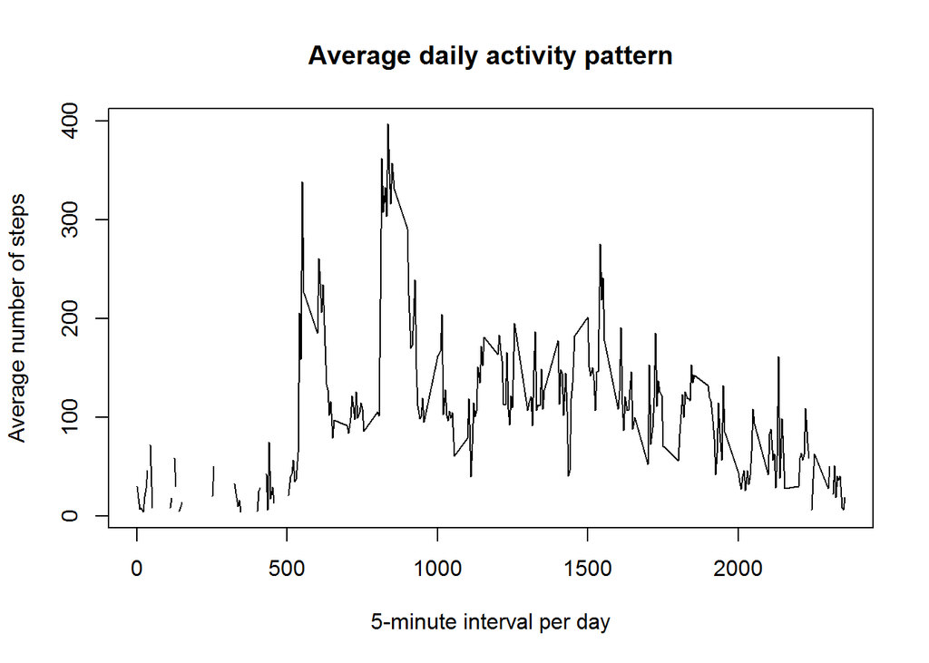

```r
dat_df <- dat %>%
    filter(week == "weekday")

interval_day_df <- tapply(dat_df$steps, dat_df$interval, mean, na.rm = TRUE)
interlist_df <- unique(dat_df$interval)

df <- data.frame(interval = interlist_df, steps = interval_day_df)

plot(df$interval, df$steps, type = "l", xlab = "5-minute interval per day",
     ylab = "Average number of steps",
     main = "Average daily activity pattern")
```